# flexdashboard

[figure not shown]

[figure not shown]

[figure not shown]

Using flexdashboard - https://rmarkdown.rstudio.com/flexdashboard/using.html

# はじめに

ダッシュボードはデータを俯瞰するために有用なツールです。Rでは`flexdashboard`パッケージを用いることで、R Markdownによる静的ダッシュボードが作成できます。静的といっても`htmlwidgets`をサポートしていますのでインタラクティブなグラフィックオブジェクトを配置するは可能です。また、shinyサーバを用いることで動的なダッシュボードの作成にも対応しています。  
`flexdashboard`は、その名の通りフレキシブルにオブジェクトを配置することができ（rowまたはcolumnベースの格子配列）、ウィンドウのリサイズにも自動的に対応します。  
記述は前述のようにR Markdownを用いますので、いたってシンプルです。YAMLに`flexdashboard`の出力であることを指定して、配置したいオブジェクトを記述しknitするだけで、最もベーシックなダッシュボードが作成できます。試しに以下のコードを実行してみてください。

```
---
title: "flexdashboard"
output:
  flexdashboard::flex_dashboard
---

### Object Area 1

### Object Area 2
```

二段のダッシュボードが作成できたはずです。  
ダッシュボード内に配置できるオブジェクトはR Markdownで出力できるオブジェクトであれば、ほぼ問題なく配置可能です。ただし、表に関してはYAMLで`df_print`オプションが利用出来ませんので、`knitr::kabele`関数や`DT::datatable`関数などを用いて表オブジェクトを作成するようにしてください。

knitr::kableでの表示例

|  | Sepal.Length | Sepal.Width | Petal.Length | Petal.Width | Species |
| --- | --- | --- | --- | --- | --- |
| 1 | 5.1 | 3.5 | 1.4 | 0.2 | setosa |
| 2 | 4.9 | 3 | 1.4 | 0.2 | setosa |
| … | … | … | … | … | NA |
| 149 | 6.2 | 3.4 | 5.4 | 2.3 | virginica |
| 150 | 5.9 | 3 | 5.1 | 1.8 | virginica |

# YAML

### YAML

`flexdashboard`で利用できるYAML設定は基本的にはR Markdown（HTML document）と同様ですが、`df_print`のように利用できない項目もあります。

```
---
title: "flexdashboard"
output:
  flexdashboard::flex_dashboard:
    css:
    favicon:
    fig_mobile:
    logo:
    md_extensions: -ascii_identifiers
    navbar:
    orientation: columns or rows
    self_contained: true or false
    social:
    storyboard: true or false
    theme: default
    vertical_layout: fill or scroll
---
```

### 利用可

| YAML Option | 説明 |
| --- | --- |
| css: | カスタムCSSファイルの指定 |
| favicon: | faviconファイルの指定 |
| fig_mobile: | モバイル画面用画像を作成するか否か（true or false） |
| logo: | navbarに表示するロゴの指定（自動的に縮小されないのでサイズに注意） |
| md_extensions: | -ascii_identifiers |
| navbar: | navbarの設定（詳細はNav-barメニュー参照方） |
| orientation: | 分割方向の指定（columns or rows） |
| self_contained: | ファイルを一つにまとめるか否か（true or false） |
| social: | SNSシェアリンクの作成 |
| source_code: | ソースコードを埋め込んでメニュー表示をするか否か（true or false） |
| storyboard: | ストーリーボード機能を使うか否か（true or false） |
| theme: | bootswatchテーマ（defaultはcosmo相当、typeはinverseが適用されるっぽい） |
| vertical_layout: | 縦方向の表示方法（fill or scroll） |

### 利用不可

| YAML Option | 説明 |
| --- | --- |
| code_folding: | 指定してもコードは表示されない（元々コードは表示されないので） |
| df_print: | 指定するとknit時にSTOPエラーになる |
| type: | 指定するとknit時にエラーが出て無視される |
| toc: | 指定してもエラーは出ないが無視される |

# 配置

## Coloumn

### 分割配置

`flexdashboard`における配置はR Markdownの見出し（Header `#`や`##`, `###`）を用います。これにより画面を分割してオブジェクエリアを配置することが可能になります。

| Level | 配置 | 備考 |
| --- | --- | --- |
| 1（`#`） | 最上段のメニュー（マルチページ指定） | `=====`での指定も可 |
| 2（`##`） | 列（Coloumn）または行（Row）の分割指定（デフォルとでは列方向に分割） | `-----`での指定も可 |
| 3（`###`） | レベル2内に配置するオブジェクトエリア指定（レベル2が列なら行方向に、行なら列方向に配置される） |  |

なお、列または行方向に分割する際には、分割割合を指定することが可能です。分割割合は合計で**`1000`**になるように調整するのが好ましいようです。また、メニュー（レベル1）ごとに分割方向を変更することも可能です。

```
---
title: "Multi page and Page rientation"
output:
  flexdashboard::flex_dashboard
---

# Menu A

## Coloumn {data-width=600}

### Object Area 1

## Coloumn {data-width=400}

### Object Area 2


Menu B {data-orientation=rows}
==============================================================================

Row {data-height=650}
------------------------------------------------------------------------------

### Object Area 3

Row {data-height=350}
------------------------------------------------------------------------------

### Object Area 4
```

### タブ配置

`flexdashboard`におけるオブジェクエリアの配置方法としては分割配置以外にタブ配置があります。

| Level | 配置 | 備考 |
| --- | --- | --- |
| 1（`#`） | タブ配置不可（マルチページメニュー自体がタブのようなもの） |  |
| 2（`##`） | タブ配置の指定はこのレベルのみ | {.tabset} |
| 3（`###`） | タブになるレベルで、このレベル以下にタブ配置は不可 |  |

```
---
title: "Multi page and Page rientation"
output:
  flexdashboard::flex_dashboard
---

## Coloumn 1 {data-width=600 .tabset}

### Tabbed Object Area 1

### Tabbed Object Area 2


## Coloumn 2 {data-width=400}

### Untabbed Object Area
```

なお、タブがエリア内に収まらない場合は複数段に描画されますのでタブ数の制限は特にありません。ただし、タブ名は重複しないように設定しないと切り替えができません。

### Tab 2

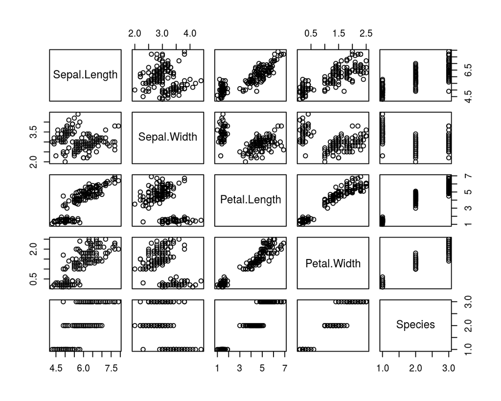

# 階層化

### 階層化

メニューは一段階のみ階層化することができます。階層化メニューごとに分割方向を変更することもできます。

```
---
title: "Menu"
output:
  flexdashboard::flex_dashboard
---

# Second Level Menu 1 {data-navmenu="First Level Menu" data-orientation=cols}

### Object Area 1

### Object Area 2


# Second Level Menu 2 {data-navmenu="First Level Menu" data-orientation=rows}

### Object Area 3

### Object Area 4
```

# 階層化

### 階層化

メニュー名についてはタブと異なり重複していても切り替えてくれます。

# オプション

### Object Area Options

オブジェクトエリアは、ヘッダー消去、フッター追加が可能です。ヘッダーはレベル3（`###`）で指定した文字列が自動的にヘッダーとして表示されますが`{.no-title}`を指定すると非表示にすることができます。一方、フッターは`>`で指定することで表示が可能になります。

```
---
title: "Menu"
output:
  flexdashboard::flex_dashboard
---

### Object Area 1 {.no-title}

> Note

### Object Area 2

> Note
```

> Note はこのように表示されます

# Nav-bar

### [Navigation Bar](https://rmarkdown.rstudio.com/flexdashboard/using.html#navigation_bar)

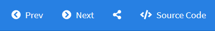

メニューの右側にこのようなメニューを表示させる場合、YAMLの`output`に以下のように指定をします。リンクは固定リンクとなる点に留意してください。

```
---
output:
  flexdashboard::flex_dashboard:
    navbar:
      - { title: "Prev", icon: "fa-chevron-circle-left", href: ""}
      - { title: "Next", icon: "fa-chevron-circle-right ", href: ""}
    social: [ "menu" ]
    source_code: embed
---
```

| 設定 | 概要 |
| --- | --- |
| navbar | HTMLのリンクを設定します。アイコン表示は常にタイトル文字の左側になります。 |
| social | SNSシェアリンクを作成するためのリンク集が表示されます。 |
| source_code | flexdashboards自体のコードが表示されるようになります。 |

このようなリンクを利用するとプロジェクトごとにflexdashboardページを作成し、順次表示させるような使い方ができます。

# Storyboards

## [Storyboards](https://rmarkdown.rstudio.com/flexdashboard/using.html#storyboards) style

### Storyboadsは表示を最大三分割して表示することができる表示形式です。最上段は画面切り替えリンクを兼ねた要約表示部分です。

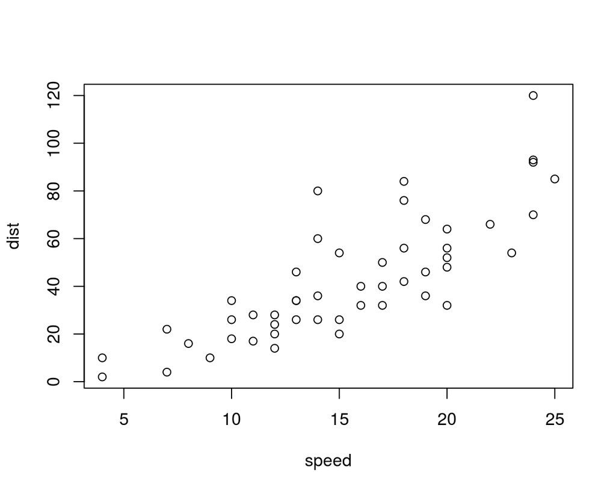

> この画面がメインとなるフレームです。

```
# Storyboards {.storyboard}

### Frame 1

***

Some commentary about Frame 1.
```

なお、Commentaryフレームではフッター（ノート）を記述することはできません。

### 紙芝居のようにストーリー立ててデータを見せることができます。ヘッダーの代わりにこのような切り替えフレームが表示されます。

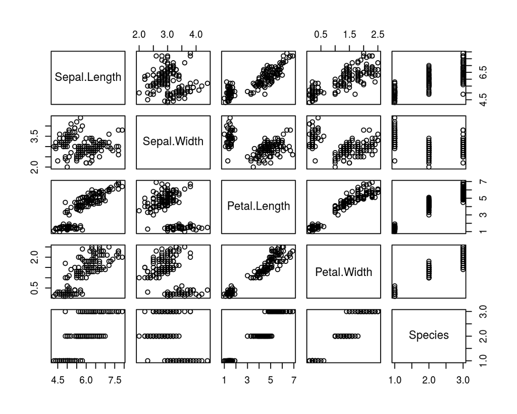

### 切り替えフレームの数に制限はなく、画面からあふれた場合は自動的に左右にスクロールしてくれます。

|  | mpg | cyl | disp | hp | drat | wt | qsec | vs | am | gear | carb |
| --- | --- | --- | --- | --- | --- | --- | --- | --- | --- | --- | --- |
| Mazda RX4 | 21 | 6 | 160 | 110 | 3.9 | 2.62 | 16.46 | 0 | 1 | 4 | 4 |
| Mazda RX4 Wag | 21 | 6 | 160 | 110 | 3.9 | 2.88 | 17.02 | 0 | 1 | 4 | 4 |
| Datsun 710 | 22.8 | 4 | 108 | 93 | 3.85 | 2.32 | 18.61 | 1 | 1 | 4 | 1 |
| … | … | … | … | … | … | … | … | … | … | … | … |
| Ferrari Dino | 19.7 | 6 | 145 | 175 | 3.62 | 2.77 | 15.5 | 0 | 1 | 5 | 6 |
| Maserati Bora | 15 | 8 | 301 | 335 | 3.54 | 3.57 | 14.6 | 0 | 1 | 5 | 8 |
| Volvo 142E | 21.4 | 4 | 121 | 109 | 4.11 | 2.78 | 18.6 | 1 | 1 | 4 | 2 |